# Plotting Growth Curves

14 februari, 2025

# 1 Introduction

The data that we are going to use for this exercise is published in the mBio paper (Niggli S 2023). It can be found online on: https://doi.org/10.6084/m9.figshare.23578086.v1 It describes the OD600 (growth) of the *Staphylococcus aureus* strain **JE2** in different media.

# 2 Reading in Data and Plotting Growth Curves

```r
fN <- "JE_growth_final.txt" # us this txt file that is copy pasted spread sheet from excel tab separated
dat <- read.table(fN, header = T, sep = "\t", stringsAsFactors = TRUE)
```

```r
fN <- "JE_growth_final.txt" # us this txt file that is copy pasted spread sheet from excel tab separated
dat <- read.table(fN, header = T, sep = "\t", stringsAsFactors = TRUE)
```

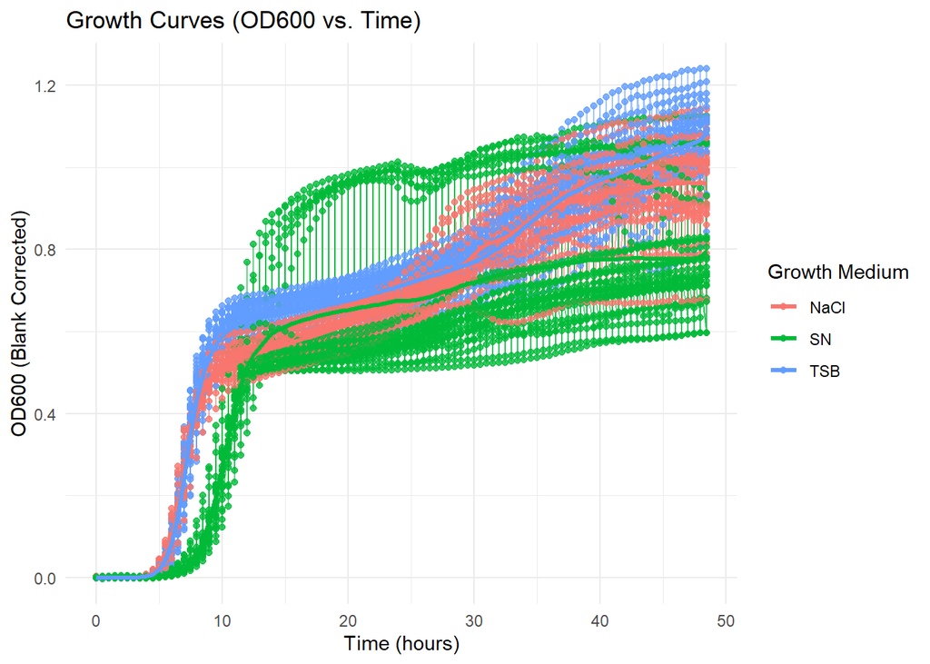

[output not shown]

[output not shown]

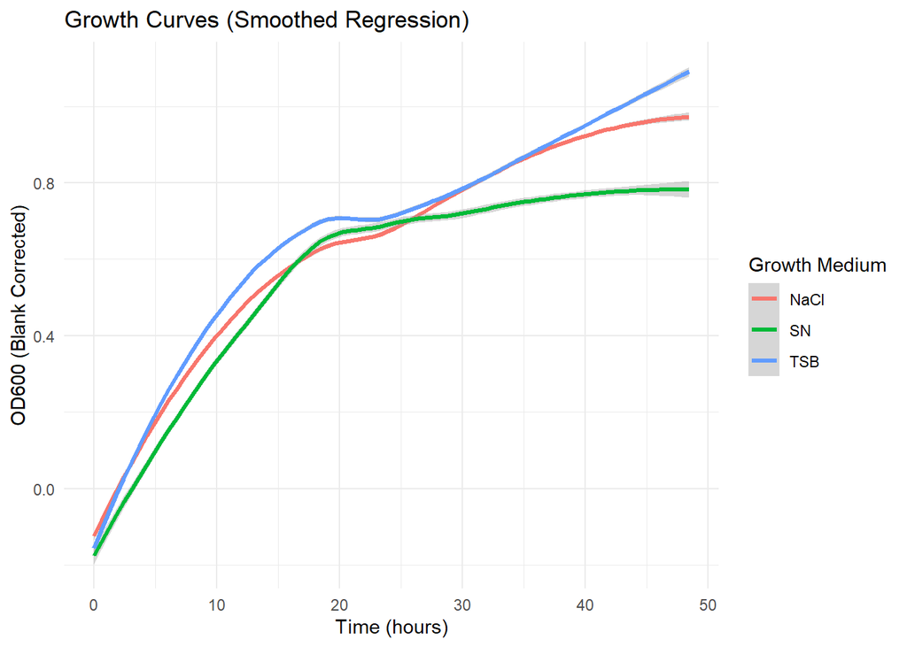

# 3 Session Information

**R version 4.4.1 (2024-06-14 ucrt)**

**Platform:** x86_64-w64-mingw32/x64

**locale:** *LC_COLLATE=Dutch_Netherlands.utf8*, *LC_CTYPE=Dutch_Netherlands.utf8*, *LC_MONETARY=Dutch_Netherlands.utf8*, *LC_NUMERIC=C* and *LC_TIME=Dutch_Netherlands.utf8*

**attached base packages:** *stats*, *graphics*, *grDevices*, *utils*, *datasets*, *methods* and *base*

**other attached packages:** *dplyr(v.1.1.4)*, *ggplot2(v.3.5.1)* and *readr(v.2.1.5)*

**loaded via a namespace (and not attached):** *Matrix(v.1.7-2)*, *gtable(v.0.3.6)*, *jsonlite(v.1.8.9)*, *crayon(v.1.5.3)*, *compiler(v.4.4.1)*, *Rcpp(v.1.0.14)*, *tidyselect(v.1.2.1)*, *jquerylib(v.0.1.4)*, *splines(v.4.4.1)*, *scales(v.1.3.0)*, *yaml(v.2.3.10)*, *fastmap(v.1.2.0)*, *lattice(v.0.22-6)*, *R6(v.2.5.1)*, *labeling(v.0.4.3)*, *generics(v.0.1.3)*, *knitr(v.1.49)*, *tibble(v.3.2.1)*, *pander(v.0.6.5)*, *bookdown(v.0.42)*, *munsell(v.0.5.1)*, *bslib(v.0.9.0)*, *pillar(v.1.10.1)*, *tzdb(v.0.4.0)*, *rlang(v.1.1.4)*, *cachem(v.1.1.0)*, *xfun(v.0.50)*, *sass(v.0.4.9)*, *cli(v.3.6.3)*, *withr(v.3.0.2)*, *magrittr(v.2.0.3)*, *mgcv(v.1.9-1)*, *digest(v.0.6.37)*, *grid(v.4.4.1)*, *rstudioapi(v.0.17.1)*, *hms(v.1.1.3)*, *nlme(v.3.1-167)*, *lifecycle(v.1.0.4)*, *vctrs(v.0.6.5)*, *evaluate(v.1.0.3)*, *glue(v.1.7.0)*, *farver(v.2.1.2)*, *colorspace(v.2.1-1)*, *rmarkdown(v.2.29)*, *tools(v.4.4.1)*, *pkgconfig(v.2.0.3)* and *htmltools(v.0.5.8.1)*

# References

Niggli S, Poveda L, Schwyter L. 2023. “Rapid and Strain-Specific Resistance Evolution of Staphylococcus Aureus Against Inhibitory Molecules Secreted by Pseudomonas Aeruginosa.” *mBio*. https://doi.org/10.1128/mbio.03153-22.